# Getting started with R

FA515: Pharmaceutical Physical Chemistry

Author

Sebastian Jakobsen

Published

August 30, 2026

## 1 Why R (and this guide)

In this course, R is used to work with data: plotting it, fitting models to it, and pulling numbers like rate constants or activation energies out of those models. This guide introduces the R skills that support that work, starting from installing R itself. It is written as a reference. You can read it start to finish before your first session with data, or come back to a specific section whenever something in a task looks unfamiliar.

If you would rather see the R basics walked through on video first, this one is a good starting point: [Introduction to R (YouTube)](https://www.youtube.com/watch?v=FY8BISK5DpM&t=315s).

## 2 Installing R and RStudio

You need two separate programs.

- **R** is the actual programming language and the engine that runs your code.
- **RStudio** is a separate program, an interface (an “IDE”) that makes working with R considerably easier: it gives you a script editor, a console, a plot viewer, and a file browser in a single window.

Install them in this order:

1. Install R first: https://cran.r-project.org/ (choose the version for your operating system).
2. Install RStudio Desktop second: https://posit.co/download/rstudio-desktop/.

RStudio needs R to already be installed, since RStudio itself does not contain the R language, it just provides a nicer way to use it. Once both are installed, you only ever need to open RStudio; it starts R for you in the background.

## 3 Finding your way around RStudio

When you open RStudio, you will typically see four panes:

- **Script** (usually top-left): where you write and save code, in files ending in `.R` or `.qmd`. This is where most of your work happens.
- **Console** (usually bottom-left): where code is actually executed, one command at a time. You can type directly into the console, but anything typed there is not saved anywhere.
- **Environment** (usually top-right): a list of the objects (data, results, models) that currently exist in your R session.
- **Plots / Files / Help** (usually bottom-right): plots appear here, along with a file browser and the help viewer.

When RStudio first opens, there is usually no script pane visible at all, only the console. This is because a script is a file, and no file has been created or opened yet. To create one:

`File → New File → R Script` (or the keyboard shortcut `Ctrl+Shift+N`, `Cmd+Shift+N` on Mac) opens a new, empty `.R` file in the script pane. This is a plain text file that will hold your code.

`File → New File → Quarto Document` creates a `.qmd` file instead. A Quarto document mixes written text with chunks of R code, and can be “rendered” into a formatted document (for example, HTML) showing both the code and its output together (for instance, this guide is created using a Quarto document). A plain `.R` script only ever contains code, with comments (lines starting with `#`) as the only text allowed alongside it.

Either file type needs to be saved before it is useful: `Ctrl+S` (`Cmd+S` on Mac), then choose a location and a filename ending in `.R` or `.qmd`. If you are working inside an RStudio Project (see the next section), save it somewhere inside that project’s folder, so it stays organised alongside the data it uses.

To run a line of code from a script, place your cursor on that line and press `Ctrl+Enter` (`Cmd+Enter` on Mac). It is good practice to always write code in a script and run it from there, rather than typing directly into the console: a script is a saved, repeatable record of exactly what you did, while anything typed only into the console is lost once you close R.

## 4 Files, folders, and the working directory

R always has a working directory: a specific folder on your computer that it treats as “home” for the current session. When you write `read_csv("data.csv")`, R looks for `data.csv` inside the working directory, not just anywhere on your computer. This is one of the most common sources of confusion for people new to R, so it is worth understanding early.

You can check your current working directory at any time:

```r
getwd()
```

It is possible to change the working directory manually with `setwd()`, but this is not recommended: a path that works on your computer (for example, `C:/Users/yourname/Documents/...`) will not work on someone else’s, or even on your own computer after moving files around.

The recommended approach instead is to work inside an RStudio Project. In RStudio, choose `File → New Project`, and pick a folder for your course work. Every file inside that project folder can then be referred to with a short, relative path (for example, `"data/kinetics_data.csv"`), rather than a full path starting from your hard drive. When you open the project (by double-clicking its `.Rproj` file), RStudio automatically sets the working directory to that project folder, so paths written by anyone, on any computer, keep working.

A simple, sensible folder structure inside a project might look like:

```
my_project/
├── my_project.Rproj
├── analysis.R
└── data/
    └── kinetics_data.csv
```

with a script then reading the data as `read_csv("data/kinetics_data.csv")`.

## 5 R as a calculator

Before doing anything else, it helps to see that R is, at its simplest, just a calculator:

```r
2 + 2
```

```
[1] 4
```

```r
10 / 4
```

```
[1] 2.5
```

```r
2^3        # exponent (2 to the power of 3)
```

```
[1] 8
```

```r
(5 + 3) * 2
```

```
[1] 16
```

The standard order of operations applies: parentheses first, then exponents (`^`), then multiplication and division (`*`, `/`), then addition and subtraction (`+`, `-`). If you are ever unsure how an expression will be evaluated, adding parentheses never hurts and often makes the intention clearer to read later.

## 6 Objects and assignment

Rather than just calculating a value and discarding it, you usually want to store it, so it can be reused. This is done with the assignment arrow `<-`:

```r
x <- 5
y <- 2
x * y
```

```
[1] 10
```

Notice that assigning a value does not print anything. The value `5` is now stored under the name `x`, and R stays quiet about it. To see the value again, type the object’s name on its own line:

```r
x
```

```
[1] 5
```

A few rules and conventions for naming objects: names cannot start with a number, cannot contain spaces, and are case-sensitive (`x` and `X` are different objects). Use an underscore in place of a space, for example `rate_constant` rather than `rate constant`. Once created, an object stays available for the rest of your session (and appears in the Environment pane) until you overwrite it or restart R.

## 7 Vectors

A vector is simply a sequence of values of the same type, stored together as one object. Vectors are built with `c()` (“combine”):

```r
temps_C <- c(20, 25, 30, 35)
temps_C
```

```
[1] 20 25 30 35
```

Two properties of vectors are worth knowing from the start. First, operations apply to every element at once, without needing to repeat the calculation manually for each value:

```r
temps_C + 273.15
```

```
[1] 293.15 298.15 303.15 308.15
```

Second, individual elements can be pulled out using square brackets and a position (starting at 1, not 0):

```r
temps_C[1]     # first element
```

```
[1] 20
```

```r
temps_C[2:3]   # second and third elements
```

```
[1] 25 30
```

## 8 Comparisons and booleans

A boolean is a value that is either `TRUE` or `FALSE`. In R, comparisons between numbers (or other values) produce booleans:

```r
5 > 3
```

```
[1] TRUE
```

```r
5 == 5     # note: == tests equality, a single = does not
```

```
[1] TRUE
```

```r
5 != 3     # "not equal to"
```

```
[1] TRUE
```

The comparison operators are `==`, `!=`, `<`, `>`, `<=`, `>=`. Applied to a vector, a comparison is evaluated element by element, producing a vector of `TRUE`/`FALSE` values:

```r
temps_C > 25
```

```
[1] FALSE FALSE  TRUE  TRUE
```

Multiple conditions can be combined with `&` (“and”, both must be true) and `|` (“or”, at least one must be true):

```r
temps_C > 20 & temps_C < 35
```

```
[1] FALSE  TRUE  TRUE FALSE
```

This matters beyond simple arithmetic checks: as shown below, this is exactly the logic used inside `filter()` to decide which rows of a data set to keep.

## 9 Functions

A function takes some input (its arguments) and returns an output. Most of what you do in R, beyond basic arithmetic, involves calling functions:

```r
sqrt(16)
```

```
[1] 4
```

```r
mean(temps_C)
```

```
[1] 27.5
```

```r
round(3.14159, 2)
```

```
[1] 3.14
```

Arguments can be given positionally, in the order the function expects them (`round(3.14159, 2)`), or by name (`round(x = 3.14159, digits = 2)`). Both produce the same result; using names becomes especially useful once a function takes several arguments, since it makes clear which value is going where without needing to remember the exact order.

If you are unsure what a function does, or what arguments it accepts, ask R directly:

```r
?round
```

This opens the function’s help page, which lists every argument and usually includes a short example. It can also help to search online for the function name (for example, “round function R”), or to ask an AI assistant.

## 10 Packages

Base R (what you get immediately after installing it) already includes a great many functions, but a lot of commonly used functionality, reading CSV files, reshaping data, and plotting among them, is not built in by default. Instead, it lives in add-on packages: bundles of functions that someone else has written and made available to install.

`tidyverse` is one such package (in fact, a collection of several packages that work well together, including `dplyr` and `ggplot2`, which are used throughout this guide). It needs to be installed once per computer, and then loaded once at the start of every R session:

```r
install.packages("tidyverse")   # only needed once, ever, per computer
library(tidyverse)               # needed at the start of every session
```

If you see an error such as `could not find function`, the most likely cause is a missing `library()` call for the package that function belongs to.

## 11 Data frames and reading in data

A data frame, or tibble (the tidyverse’s version of a data frame), is a table: each row is an observation, and each column is a variable. In practice, you will most often get one by reading in a CSV file:

```r
my_data <- read_csv("data/some_file.csv")
```

Following on from the working directory discussion above, this only works if the path given matches where the file actually is, relative to your project folder.

A tibble can also be built directly, without reading a file, which is useful for small examples:

```r
df <- tibble(x = c(1, 2, 3), y = c(4, 5.2, 5.9))
df
```

```
# A tibble: 3 × 2
      x     y
  <dbl> <dbl>
1     1   4
2     2   5.2
3     3   5.9
```

Before working further with any data frame, it is good practice to look at it first. A useful function for this:

```r
glimpse(df)   # column names, data types, and the first few values
```

```
Rows: 3
Columns: 2
$ x <dbl> 1, 2, 3
$ y <dbl> 4.0, 5.2, 5.9
```

A single column can be pulled out with `$`:

```r
df$x
```

```
[1] 1 2 3
```

## 12 Core dplyr verbs

`dplyr` is the tidyverse package for working with data frames: filtering rows, creating columns, sorting, and similar everyday tasks. Its functions are often called “verbs”, since each one describes a single action to perform on the data, such as “mutate”, “filter”, or “arrange”. A small set of these verbs covers most everyday data wrangling, and each is introduced separately below with a simple, standalone example.

### 12.1 `mutate()`: add or change a column

`mutate()` adds a new column to a data frame, calculated from existing columns:

```r
mutate(df, z = x + y)
```

```
# A tibble: 3 × 3
      x     y     z
  <dbl> <dbl> <dbl>
1     1   4     5
2     2   5.2   7.2
3     3   5.9   8.9
```

This does not change `df` itself, it returns a new data frame with the added column, which is only kept if assigned back:

```r
df <- mutate(df, z = x + y)
```

Multiple columns can be created in one call, separated by commas, and a later column can immediately use one defined earlier in the same call:

```r
mutate(df, z = x + y, w = z * 2)
```

```
# A tibble: 3 × 4
      x     y     z     w
  <dbl> <dbl> <dbl> <dbl>
1     1   4     5    10
2     2   5.2   7.2  14.4
3     3   5.9   8.9  17.8
```

### 12.2 `filter()`: keep only some rows

`filter()` keeps every row where a condition (built using the comparison operators from the section above) evaluates to `TRUE`:

```r
filter(df, x > 1)
```

```
# A tibble: 2 × 3
      x     y     z
  <dbl> <dbl> <dbl>
1     2   5.2   7.2
2     3   5.9   8.9
```

### 12.3 `arrange()`: sort rows

`arrange()` reorders the rows of a data frame based on the values in one or more columns, without changing the data itself:

```r
arrange(df, y)
```

```
# A tibble: 3 × 3
      x     y     z
  <dbl> <dbl> <dbl>
1     1   4     5
2     2   5.2   7.2
3     3   5.9   8.9
```

By default this sorts in ascending order (smallest first). Wrap the column in `desc()` to sort descending (largest first):

```r
arrange(df, desc(y))
```

```
# A tibble: 3 × 3
      x     y     z
  <dbl> <dbl> <dbl>
1     3   5.9   8.9
2     2   5.2   7.2
3     1   4     5
```

### 12.4 `slice()`: pick rows by position

`slice()` picks out rows by their position (row number), rather than by sorting or by a condition. This is often used right after `arrange()`, to pull out a specific rank, for example the row with the highest R² after sorting by it:

```r
slice(df, 1)      # first row only
```

```
# A tibble: 1 × 3
      x     y     z
  <dbl> <dbl> <dbl>
1     1     4     5
```

```r
slice(df, 1:2)    # first two rows
```

```
# A tibble: 2 × 3
      x     y     z
  <dbl> <dbl> <dbl>
1     1   4     5
2     2   5.2   7.2
```

## 13 Chaining steps: nested code vs. the pipe `%>%`

A single verb is rarely the whole task. More often, several steps need to happen one after another, for example: add a column, sort by it, then keep only the top row. Written directly, this means nesting one function call inside another:

```r
slice(arrange(mutate(df, z = x + y), desc(z)), 1)
```

```
# A tibble: 1 × 3
      x     y     z
  <dbl> <dbl> <dbl>
1     3   5.9   8.9
```

This produces the correct result, but is hard to read: the first step that actually happens (`mutate`) is the innermost call, so the code has to be read from the inside out, in the opposite order to how it is executed.

The pipe operator, `%>%`, solves this by taking whatever is on its left and passing it in as the first argument to the function on its right. The same calculation, written with the pipe:

```r
df %>%
  mutate(z = x + y) %>%
  arrange(desc(z)) %>%
  slice(1)
```

```
# A tibble: 1 × 3
      x     y     z
  <dbl> <dbl> <dbl>
1     3   5.9   8.9
```

Both versions produce an identical result. The piped version reads top-to-bottom, in the same order the steps are actually carried out, which is generally much easier to follow, especially as the number of steps grows.

## 14 Two math functions: `log()` and `exp()`

Two functions worth knowing specifically, beyond basic arithmetic, are the natural logarithm and its inverse:

```r
log(10)    # natural log (ln), not log base 10
```

```
[1] 2.302585
```

```r
exp(1)     # e to the power of 1
```

```
[1] 2.718282
```

These come up whenever a relationship needs to be transformed into a straight line before it can be fitted with linear regression, for example, an exponential decay becomes linear once you take the log of the concentration. One thing worth watching for: `log()` of zero or a negative number returns `-Inf` or `NaN` (both meaning “not a valid number”), without raising an error. If a result further down a calculation looks wrong, this is a common place to check first.

## 15 Fitting a straight line: `lm()`

Linear regression finds the straight line that best fits a set of points: specifically, the line that minimises the total (squared) distance between the line and each data point. You do not need to derive this by hand; the `lm()` function (“linear model”) does it directly:

```r
model <- lm(y ~ x, data = df)
```

The formula `y ~ x` reads as “model y as a function of x”, and mirrors how you would write it mathematically. Note that `y` and `x` here are not literal letters to copy: they must be replaced with the actual column names from your data. For example, fitting concentration against time would be written `lm(concentration ~ time, data = kinetics_data)`, using whatever the columns are actually called in that data frame.

The fitted result is stored in an object, here called `model`, though it could just as easily be named something else. This object contains, among other things, the equation of the best-fit line and information about how well it fits the data. Two pieces are used most often:

```r
coef(model)
```

```
(Intercept)           x
   3.133333    0.950000
```

This returns the intercept and slope of the fitted line, in that order. `coef(model)[[1]]` is the intercept, `coef(model)[[2]]` is the slope; the double square brackets pull out a single value from the result.

Beyond the coefficients, calling `summary()` on the model gives a fuller report of the fit, including how well the line actually matches the data. One especially useful value from that report is R²:

```r
summary(model)$r.squared
```

```
[1] 0.9774368
```

R² (r-squared) is a number between 0 and 1 describing how well the line fits the data: closer to 1 means the points fall close to the line, closer to 0 means they are scattered further from it. Note that R² is not stored directly on `model`; it is one part of the larger result returned by `summary()`, which is why it has to be accessed this way rather than with `model$r.squared`.

## 16 Plotting with ggplot2

Every plot built with `ggplot2` follows the same basic pattern: give it a data frame, map columns to visual properties like x and y position with `aes()`, and then add one or more layers with `+`:

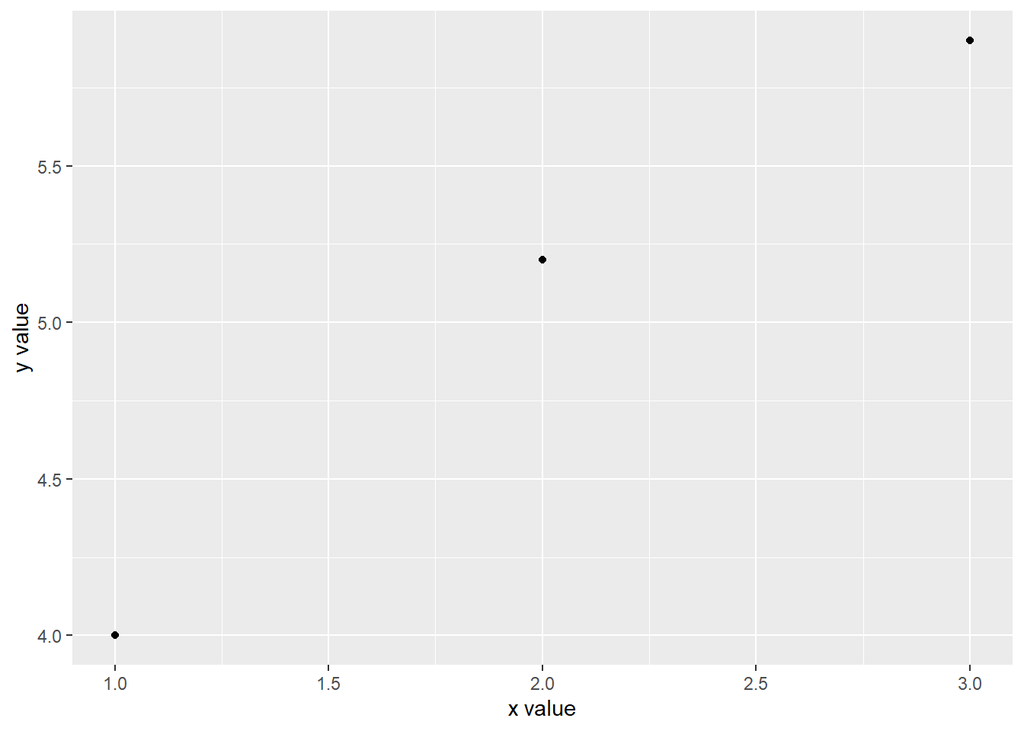

```r
ggplot(df, aes(x = x, y = y)) +
  geom_point() +
  labs(x = "x value", y = "y value")
```

A fitted regression line can be added directly, without first needing to run `lm()` separately:

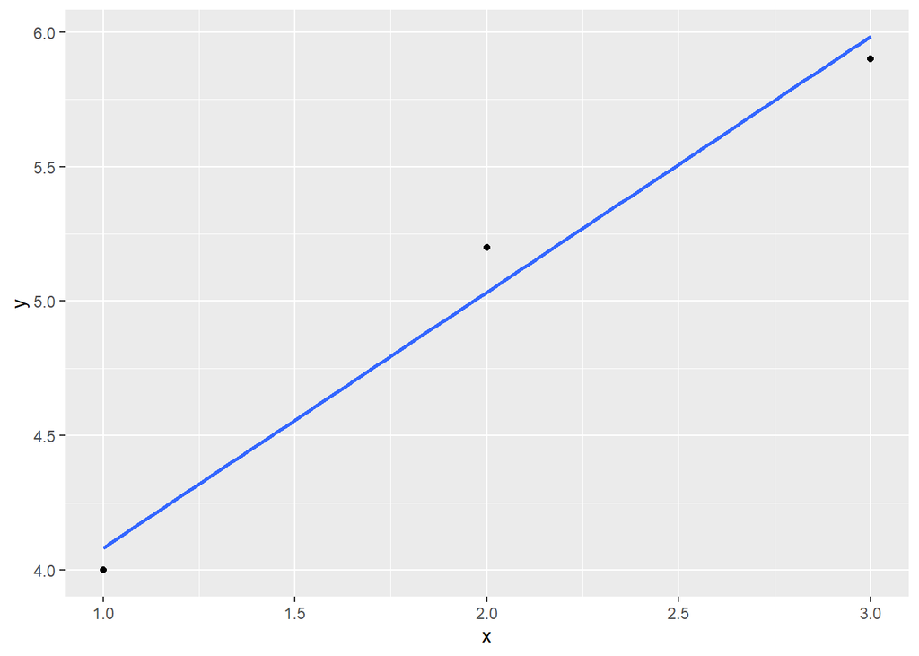

```r
ggplot(df, aes(x = x, y = y)) +
  geom_point() +
  geom_smooth(method = "lm", se = FALSE)
```

### 16.1 Styling a plot

A few arguments come up repeatedly when adjusting how a plot looks. None of them change the underlying data or any calculated result; they only affect appearance.

- `labs()` sets axis and plot titles, for example `labs(x = "Time (days)", y = "Concentration (mg/mL)", title = "Degradation over time")`.
- `size` (inside a `geom_`, for example `geom_point(size = 2)`) controls how large points or lines are drawn.
- `alpha` (also inside a `geom_`, for example `geom_point(alpha = 0.3)`) controls transparency, from 0 (fully invisible) to 1 (fully solid). This is particularly useful with a large number of overlapping points, where a lower alpha makes the density of the data visible instead of a single solid mass of ink.
- Colour can be used in two different ways, which are easy to confuse. Placing it inside `aes()`, as in `aes(color = group)`, maps a column in the data to colour, so that different groups get different colours automatically, along with a legend. Placing it outside `aes()`, as in `geom_point(color = "blue")`, simply sets every point to that one fixed colour, with no legend and no connection to the data.
- Themes, such as `theme_minimal()`, `theme_classic()`, or `theme_bw()`, control the overall look of the plot: background, gridlines, and fonts. They can be combined with a `base_size` argument, for example `theme_minimal(base_size = 14)`, to increase or decrease all text sizes on the plot at once.

Bringing these together, a plot with two groups, styled axis titles, larger semi-transparent points, and an adjusted theme might look like this:

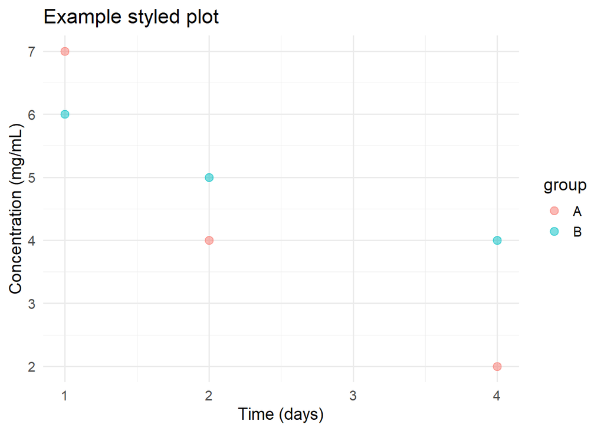

```r
df_demo <- tibble(
  x     = c(1, 2, 4, 1, 2, 4),
  y     = c(7, 4, 2, 6, 5, 4),
  group = c("A", "A", "A", "B", "B", "B")
)

ggplot(df_demo, aes(x = x, y = y, color = group)) +
  geom_point(size = 3, alpha = 0.5) +
  labs(x = "Time (days)", y = "Concentration (mg/mL)",
       title = "Example styled plot") +
  theme_minimal(base_size = 14)
```

## 17 Printing results

`cat()` combines text and numbers into a single readable line of output. `signif()` rounds a number to a chosen number of significant figures, useful for reporting a result without printing more decimal places than are meaningful:

```r
result <- 3.14159265
cat("Result =", signif(result, 3))
```

```
Result = 3.14
```

## 18 Common errors and how to handle them

Error messages in R can look intimidating at first, but most of the ones you will encounter early on fall into a small number of categories.

**could not find function “…”**: A package has not been loaded. Check that `library(tidyverse)` (or whichever package the function belongs to) has been run earlier in the session. This can also be caused by a typo in the function name, so check the spelling too.

**object ‘…’ not found**: Either there is a typo in the object’s name, or the line that creates it has not actually been run yet in this session. R only knows about objects that have already been executed, in order, from the top of the script or directly in the console; simply having a line written in your script is not enough.

**cannot open file ‘…’: No such file or directory**: This is almost always a working directory or path problem, see the section above. Check `getwd()`, and check that the file path matches where the file actually is, relative to that folder.

**non-numeric argument to binary operator**: This usually means a mathematical operation (`+`, `-`, `*`, `/`) is being applied to a column or value that is text (a character) rather than a number. Check the data type of the relevant column, for example with `glimpse()`.

**A result is unexpectedly `NA`, `NaN`, or `-Inf`**: `NA` usually means missing data. `NaN` or `-Inf` often comes from an invalid calculation, such as `log()` of zero or a negative number, or dividing by zero. Trace back to where the value was calculated and check the input.

**unexpected symbol, unexpected ‘)’, unexpected ‘}’, and similar**: This is a syntax error: usually a missing comma, a missing or extra bracket, or a missing `+` between `ggplot2` layers. R will point to roughly where it got confused, though the actual mistake is sometimes on the line just before.

When an error appears, it is usually worth reading it from the bottom up, and checking the Environment pane to confirm which objects actually exist and what they currently contain, rather than assuming a line ran successfully just because it was written.

More generally, when none of the categories above obviously match, the following approach tends to narrow things down:

1. **Read the error message itself**, even if it looks cryptic. It usually names the function that failed and gives some indication of what it did not like about its input.
2. **Find the line the error refers to**, and run it on its own, rather than as part of a larger block. This makes it clear exactly which step is failing, rather than guessing among several lines run together.
3. **Check the objects involved** in that line, by typing their name on their own, or using `glimpse()`, to see whether they contain what you expect. A surprising value earlier in a script is often the real cause of an error that only appears several lines later.
4. **Re-run the script from the top**, if anything is uncertain. Since R only knows about code that has actually been executed, working through a script out of order, or after editing an earlier line, is a common source of errors that are not really about the current line at all.
5. **If still stuck**, search for the exact error message online, or ask an AI assistant, pasting the relevant code and the full error message rather than just describing the problem from memory.